# Qty Accidents in Brazil - Top Cities

*Importando as bibliotecas que serão usadas. Neste notebook estou usando o Python3 e as seguintes bibliotecas: pandas e matplotlib.*

```python
import pandas as pd
import matplotlib
import matplotlib.pyplot as plt

%matplotlib inline
matplotlib.style.use('ggplot')
```

*Definição das variáveis de localização do arquivo (caminho) e nome-do-arquivo (CSV) que contem os dados que iremos analisar.*

```python
path_acc = '/home/df/ContaAzul/Ex1/data/accidents_brasil.csv'
path_reg = '/home/df/ContaAzul/Ex1/data/regions_brazil.csv'
```

*Criação de um dataframe contendo os dados de acidentes de todo o Brasil entre o período de 2003 a 2007. Estes dados são carregados a partir do arquivo CSV.*

```python
u_cols = ['ano', 'mun_cod_ibge', 'mun_nome', 'uf', 'qtd_acid_c_cat_tipicos', 'qtd_acid_c_cat_trajeto',
          'qtd_acid_c_cat_doenca_profiss', 'qtd_obitos', 'qtd_acid_s_cat']
df_acc_brz = pd.read_csv(path_acc, names=u_cols, encoding='latin-1', skiprows=1)
```

*Criação de um dataframe contendo os dados das regiões do Brasil e as suas Unidades Federativas.*

```python
u_cols = ['uf', 'regiao']
df_regions = pd.read_csv(path_reg, encoding='latin-1', usecols=(1,3), names=u_cols, skiprows=1)
```

*Criação de um novo dataframe com os dados de acidentes, porém sem as colunas de "ano", "mun_cod_ibge", qtd_obitos".*

```python
u_cols = ['mun_nome', 'uf', 'qtd_acid_c_cat_tipicos', 'qtd_acid_c_cat_trajeto',
          'qtd_acid_c_cat_doenca_profiss', 'qtd_acid_s_cat']
df_acc = df_acc_brz[u_cols]
```

*Criação de uma nova coluna que calcula o total de acidentes para cada linha.*

```python
df_acc['total_acc'] = df_acc['qtd_acid_c_cat_tipicos'] + df_acc['qtd_acid_c_cat_trajeto'] + \
df_acc['qtd_acid_c_cat_doenca_profiss'] + df_acc['qtd_acid_s_cat']
```

*Reduz o número de coluna do dataframe, deixando somente as colunas necessárias para análise.*

```python
u_cols = ['mun_nome', 'uf', 'total_acc']
df_acc = df_acc[u_cols]
```

*Inclui uma nova coluna "regiao" no dataframe, a partir de um join.*

```python
df_acc_brazil = pd.merge(df_acc, df_regions, on='uf', how='inner')
df_acc_brazil.head()
```

|  | mun_nome | uf | total_acc | regiao |
| --- | --- | --- | --- | --- |
| 0 | IGNORADO RONDONIA | RO | 0 | NORTE |
| 1 | ALTA FLORESTA D OESTE | RO | 16 | NORTE |
| 2 | ARIQUEMES | RO | 186 | NORTE |
| 3 | CABIXI | RO | 8 | NORTE |
| 4 | CACOAL | RO | 294 | NORTE |

*Agrupa os dados por município, uf e região.*

```python
by_mun = df_acc_brazil.groupby('mun_nome')
by_uf = df_acc_brazil.groupby('uf')
by_regiao = df_acc_brazil.groupby('regiao')
```

*Agrega os dados por município e ordena os valores de forma decrescente. Em seguida, seleciona os 3 primeiros valores.*

```python
by_mun['total_acc'].sum().sort_values(ascending=False)[:3]
```

```
mun_nome
SAO PAULO         227002
RIO DE JANEIRO     98217
PORTO ALEGRE       54734
Name: total_acc, dtype: int64
```

*Agrega os dados por uf e ordena os valores de forma decrescente. Em seguida, seleciona os 3 primeiros valores.*

```python
by_uf['total_acc'].sum().sort_values(ascending=False)[:3]
```

```
uf
SP    936425
MG    264807
RS    225362
Name: total_acc, dtype: int64
```

*Agrega os dados por região e ordena os valores de forma decrescente. Em seguida, seleciona os 3 primeiros valores.*

```python
by_regiao['total_acc'].sum().sort_values(ascending=False)[:3]
```

```
regiao
SUDESTE      1436400
SUL           576150
NORDESTE      258171
Name: total_acc, dtype: int64
```

*Agrega os dados por uf e ordena os valores de forma decrescente. Em seguida, seleciona os 10 primeiros valores e apresenta estes valores em um gráfico de barras vertical.*

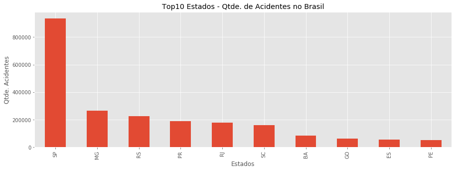

```python
top10uf = by_uf['total_acc'].sum().sort_values(ascending=False)[:10]  # 10 primeiras linhas
top10uf.plot(kind='bar', figsize=(15,5))
plt.title(u'Top10 Estados - Qtde. de Acidentes no Brasil')
plt.xlabel(u'Estados')
plt.ylabel(u'Qtde. Acidentes')
plt.show()
```

*Agrega os dados por município e ordena os valores de forma decrescente. Em seguida, seleciona os 10 primeiros valores e apresenta estes valores em um gráfico de barras vertical.*

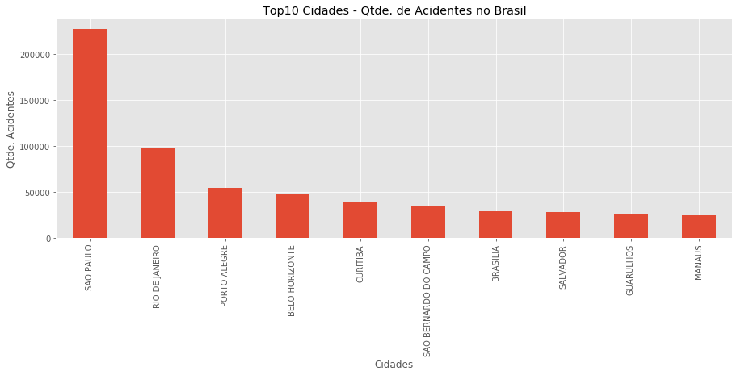

```python
top10mun = by_mun['total_acc'].sum().sort_values(ascending=False)[:10]  # 10 primeiras linhas
top10mun.plot(kind='bar', figsize=(15,5))
plt.title(u'Top10 Cidades - Qtde. de Acidentes no Brasil')
plt.xlabel(u'Cidades')
plt.ylabel(u'Qtde. Acidentes')
plt.show()
```